# The Two-Stage Prediction Model for Individualized Treatment Benefit Behind the *Collaborative Care Compass*

- Show All Code
- Hide All Code
- View Source

Stage 1: The Risk Model

Author

Affiliations

[DSSGx Munich 2026 Fellows](https://www.dssgxmunich.org/project-2026)

[Social Data Science and AI Lab, LMU Munich](https://www.stat.lmu.de/soda/en/)

[Munich Center for Machine Learning](https://mcml.ai/)

Published

October 2, 2026

# Overview

The [*Collaborative Care Compass*](https://dssgxmunich.github.io/collaborative-care-webapp/) is a research prototype to predict how collaborative care treatment components influence the PHQ-9 score for a person with depression one year from treatment start. It is developed based on individual patient data (IPD) from randomized controlled trials comparing collaborative care as intervention and usual care as control.

The model consists of two parts: The first part is a risk model, predicting depressive symptom severity at 12 months from baseline characteristics. The output of the model is a risk score, used as input to the second part which estimates how the effects of collaborative care components vary by baseline risk, following the [PATH framework by Kent et al. (2020)](https://pubmed.ncbi.nlm.nih.gov/31711134/).

**This report covers stage 1, the risk model.** Stage 2, the component network meta-analysis, is documented in a separate report, with its assumptions checked in a companion report.

# Risk Model

We believe the PATH consensus criteria on the effectiveness of risk modeling to RCT (meta-) analysis are fulfilled. There is, to our knowledge, no compatible, externally-developed risk model available to stratify trial results. We therefore develop a risk model based on the multi-trial population we carefully extracted out of IPD from 29 RCTs.

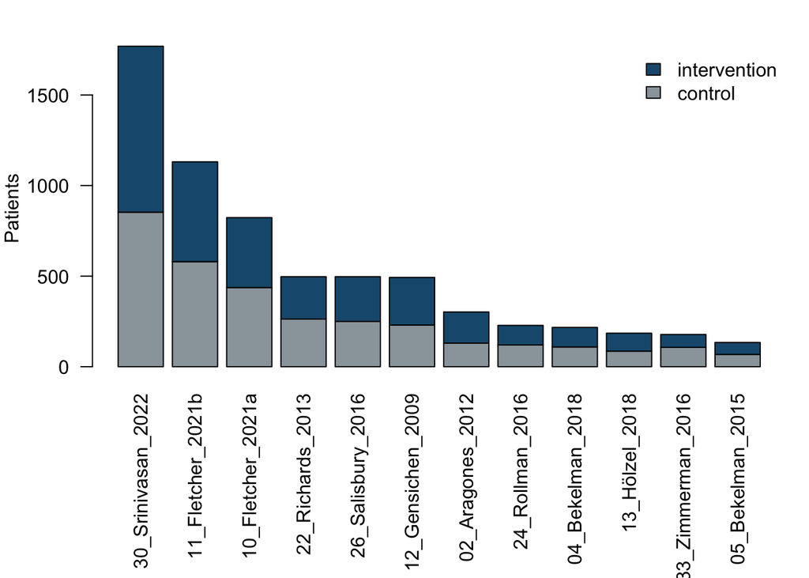

```r
library(data.table)
library(Hmisc)
library(ggplot2)
library(splines)
library(ordinal)
library(rms)
library(metafor)


# Sourcing risk_score_model.R brings in the model definition and the cohort
# path it reads, DATA_PATH.
REPO_ROOT <- rprojroot::find_root(rprojroot::has_file("pyproject.toml"))
source(file.path(REPO_ROOT, "collaborative_care_analysis", "data_analysis",
                 "risk_score_model.R"))

# The cohort is built from the harmonised IPD by
#   uv run collaborative_care_analysis/dataset.py analysis-data phq9_12mo_core
df <- load_model_data(DATA_PATH)


# inspect marginal distributions for covariates and baseline
tab <- table(df$arm, df$study_id)
tab <- tab[, order(-colSums(tab))]
par(mar = c(9, 4, 2, 1))
barplot(tab, col = c("#9AA4AA", "#195A7D"), las = 2, ylab = "Patients",
        legend.text = TRUE, args.legend = list(x = "topright", bty = "n"))
```

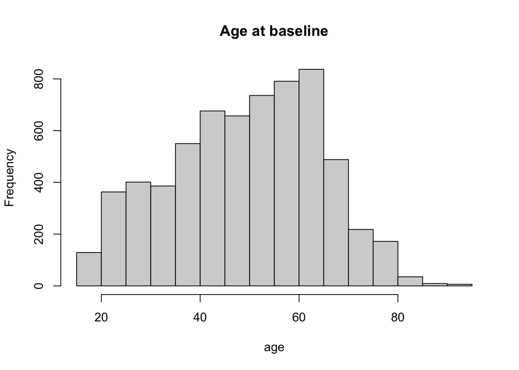

```r
par(mar = c(5, 4, 4, 2) + 0.1)
hist(df$age, main = "Age at baseline",  xlab = "age")
```

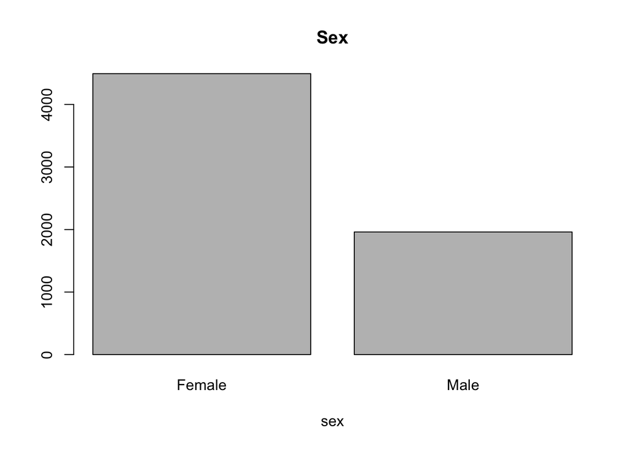

```r
barplot(table(df$sex), main = "Sex", xlab = "sex")
```

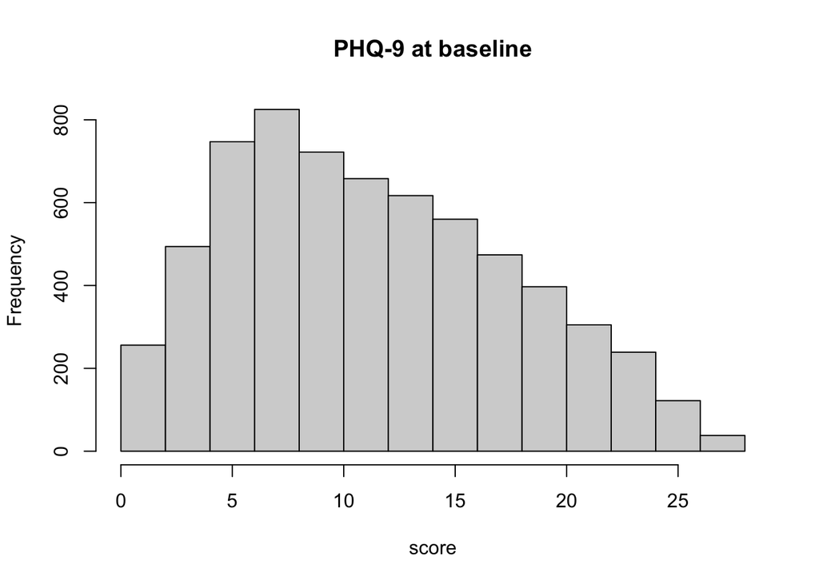

```r
hist(df$phq9_at_baseline, main = "PHQ-9 at baseline",  xlab = "score")
```

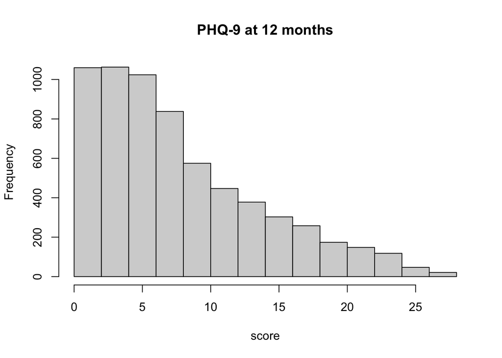

```r
hist(df$phq9_at_12mo, main = "PHQ-9 at 12 months", xlab = "score")
```

## Initial Model Specification

Let $Y^{(12)}_{ij} \in \{0, 1, \dots, 27\}$ denote the total PHQ-9 score of individual $i = 1, \dots, n_j$ in study $j = 1, \dots, 12$ at 12 months post-randomization, and $y^{(0)}_{ij}$ the known PHQ-9 score at baseline. We specify the semiparametric ordinal logistic mixed model

$$P\left(Y^{(12)}_{ij} \leq k \mid \mathbf{x}_{ij}, y^{(0)}_{ij}, \alpha_j, \gamma_j\right)
= \sigma\left(\theta_k - \eta_{ij}\right), \qquad k = 0, 1, \dots, 26,$$

with linear predictor

$$\eta_{ij} = \beta_{\text{sex}}\, \text{sex}_{ij}
+ \sum_{m=1}^{2} \beta_{\text{age},m}\, s_m(\text{age}_{ij})
+ \left(\beta_{0} + \gamma_j\right) y^{(0)}_{ij}
+ \alpha_j,$$

where

- $\theta_0 < \theta_1 < \dots < \theta_{26}$ are threshold intercepts between adjacent PHQ-9 scores,
- $\text{sex}_{ij}$ is an indicator for male sex,
- $s_1(\text{age})$ and $s_2(\text{age})$ are basis functions of a restricted cubic spline with three knots at the 10th, 50th and 90th age percentiles,
- $\text{age}_{ij}$ and $y^{(0)}_{ij}$ enter centred and scaled by their sample mean and standard deviation,
- $\gamma_j$ is a random study slope on baseline PHQ-9,
- $\alpha_j$ is a random study intercept,

and the study-level random effects are independent,

$$\alpha_j \sim \mathcal{N}\left(0, \tau_\alpha^2\right), \qquad
\gamma_j \sim \mathcal{N}\left(0, \tau_\gamma^2\right).$$

## Model Data

All models below use baseline PHQ-9 and age centered and scaled by their sample mean and standard deviation, and a spline for age with knots at the 10th, 50th and 90th percentiles.

```r
prepared <- add_centred_terms(df)
df <- prepared$data
knots_c <- age_spline_knots(df)

# fixed part is used for the design matrix and for predictions, full part adds
# the study random effects
forms <- model_formulas(knots_c)
fixed_form <- forms$fixed
model_formula <- forms$full
```

## Sample Size Calculation

We conduct a sample size calculation according to [Pate et al. (2023)](https://journals.sagepub.com/doi/10.1177/09622802231151220).

```r
# Step 1
# calculating Q, the number of predictor parameters
X <- model.matrix(fixed_form, data = df)
Q <- (ncol(X) - 1) + 1  # baseline (1) + age spline (2) + sex (1), plus the random slope

# calculating outcome proportions
counts <- df[order(phq9_at_12mo), .N, by = phq9_at_12mo]
n_obs <- sum(counts$N)
pk <- counts$N / n_obs

pairs <- CJ(r = counts$phq9_at_12mo, k = counts$phq9_at_12mo)[k > r]
pairs[counts, E_r := i.N, on = .(r = phq9_at_12mo)]
pairs[counts, E_k := i.N, on = .(k = phq9_at_12mo)]
pairs[, p_kr := (E_k + E_r) / n_obs]  # p_{k,r}

# max(R2_CS_app) for the overall multinomial model
max_r2_overall <- 1 - prod(pk^pk)^2
# fallback to R2_Nagelkerke = 0.15
R2_adj_overall <- 0.15 * max_r2_overall

# max(R2_CS_app,k,r) per one vs one sub-model
pairs[, phi_kr := E_k / (E_k + E_r)]
pairs[, max_r2 := 1 - (phi_kr^phi_kr * (1 - phi_kr)^(1 - phi_kr))^2]
pairs[, R2_adj := 0.15 * max_r2]

# Step 3: criterion (i)
S <- 0.9
crit_i_m <- function(Q, R2adj, S = 0.9) {
  Q / ((S - 1) * log(1 - R2adj / S))
}

pairs[, m_kr := crit_i_m(Q, R2_adj, S)]
pairs[, n_kr := m_kr / p_kr]
crit_i <- max(pairs$n_kr)

# Step 4: criterion (ii)
delta  <- 0.05
K <- nrow(counts)
crit_ii <- (K - 1) * Q /
  ((R2_adj_overall / (R2_adj_overall + delta * max_r2_overall) - 1) *
     log(1 - R2_adj_overall - delta * max_r2_overall))

# Step 5: criterion (iii)
alpha <- 0.05
chi <- qchisq(1 - alpha / K, df = 1)
crit_iii <- max(chi * pk * (1 - pk) / delta^2)

# Step 6: the requirement is the maximum
c(Q = Q, K = K, n_obs = n_obs,
  crit_i = crit_i, crit_ii = crit_ii, crit_iii = crit_iii,
  required = max(crit_i, crit_ii, crit_iii))
```

```
         Q          K      n_obs     crit_i    crit_ii   crit_iii   required
    5.0000    28.0000  6454.0000 62097.1795  2426.0586   298.2365 62097.1795
```

We treat the required sample size as a conservative upper bound. Our ordinal model under the proportional odds assumption likely requires a smaller sample size, since less parameters are to be estimated than for a multinomial model (see the discussion section in Pate et al.). Since two out of three criteria in the sample size calculation are fulfilled, we deem the sample size sufficient for the model we aim to fit, without risking serious overfitting.

## Ordinality and PO Assumption

Under the assumption that a predictor $X$ is linearly related to the cumulative log-odds of $\{Y^{(12)}_{ij} \leq k\}$, the ordinality assumption underlying an ordinal regression model can be checked by plotting the mean of $X$ against levels of $Y$. The stratified means should then show a consistent trend. Note that the ordinality assumption may appear to be violated due to non-linear effects of $X$ on $Y$ (see chapter 13 in Frank Harrell’s [Regression Modeling Strategies](https://link.springer.com/book/10.1007/978-3-319-19425-7)).

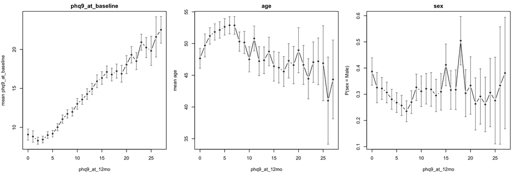

```r
x_cont <- c("phq9_at_baseline", "age")
x_all  <- c(x_cont, "sex")

# mean of X by level of Y, with 95% CIs; for a factor, the proportion in its second level
means_by_y <- function(x) {
  v     <- df[[x]]
  label <- paste("mean", x)
  if (is.factor(v)) {
    label <- paste0("P(", x, " = ", levels(v)[2], ")")
    v     <- as.numeric(v == levels(v)[2])
  }
  s <- data.table(y = df$phq9_at_12mo, v = v)[
    , .(m = mean(v), se = sd(v) / sqrt(.N)), by = y][order(y)]
  s[, `:=`(lo = m - 1.96 * se, hi = m + 1.96 * se)]
  list(means = s, label = label)
}

op <- par(mfrow = c(1, length(x_all)), mar = c(4, 4, 2, 1))
for (x in x_all) {
  r <- means_by_y(x)
  s <- r$means
  plot(s$y, s$m, type = "b", pch = 19, cex = 0.6, ylim = range(s$lo, s$hi, na.rm = TRUE),
       xlab = "phq9_at_12mo", ylab = r$label, main = x)
  arrows(s$y, s$lo, s$y, s$hi, angle = 90, code = 3, length = 0.02, col = "grey50")
}
```

```r
par(op)
```

Under the proportional odds assumption, the cumulative log-odds for different cut-points, plotted against individual predictors, should be parallel.

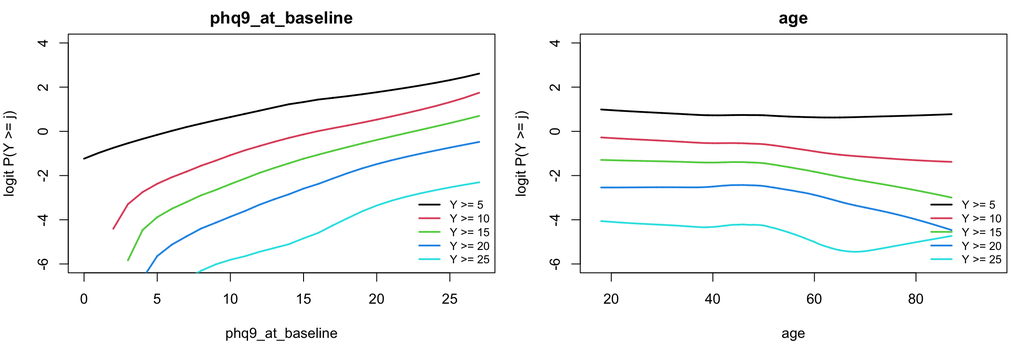

```r
cuts <- c(5, 10, 15, 20, 25)

plot_parallelism <- function(x) {
  plot(NA, xlim = range(df[[x]]), ylim = c(-6, 4),
       xlab = x, ylab = "logit P(Y >= j)", main = x)
  for (i in seq_along(cuts))
    suppressWarnings(plsmo(df[[x]], df$phq9_at_12mo >= cuts[i], fun = qlogis,
                           add = TRUE, col = i, lwd = 2))
  legend("bottomright", paste("Y >=", cuts), col = seq_along(cuts),
         lwd = 2, bty = "n", cex = 0.8)
}

op <- par(mfrow = c(1, length(x_cont)), mar = c(4, 4, 2, 1))
for (x in x_cont) plot_parallelism(x)
```

```r
par(op)
```

Compare the goodness of fit between the full PO model and letting one predictor’s coefficient vary across thresholds (partial PO).

```r
# since clmm does not support nominal_test, the random intercept and slope
# are approximated by fixed study effects and a study * baseline interaction
m_po <- clm(update(fixed_form, ordered(phq9_at_12mo) ~ . + study_id +
                     phq9_at_baseline_c:study_id),
            data = df)

# test the predictors only; the study terms are there to adjust
predictors <- grep("study_id", attr(terms(m_po), "term.labels"),
                   value = TRUE, invert = TRUE)

nt <- nominal_test(m_po, scope = predictors)
nt$LRT_per_df <- round(nt$LRT / nt$Df, 2)
nt[, c("Df", "LRT", "LRT_per_df")]
```

```
                                                                     Df     LRT
<none>
phq9_at_baseline_c                                                   26 218.285
ns(age_c, knots = age_knots[2], Boundary.knots = age_knots[c(1, 3)]) 52 162.890
sex                                                                  26  55.939
                                                                     LRT_per_df
<none>
phq9_at_baseline_c                                                         8.40
ns(age_c, knots = age_knots[2], Boundary.knots = age_knots[c(1, 3)])       3.13
sex                                                                        2.15
```

Especially, centered baseline PHQ-9 departs from the PO assumption. We nevertheless retain the more parsimonious PO model and assess whether this affects predictive performance, the core utility for of the risk model, using internal-external cross-validation.

## Internal-External Cross-Validation

Following [Steyerberg and Harrell (2016)](https://doi.org/10.1016/j.jclinepi.2015.04.005), we assess how the model performs in a setting it has not seen by internal-external cross-validation (IECV). Each study is left out once, the model is fitted to the remaining eleven, and its predictions are evaluated in the left-out study. We report

- Somers’ $D_{xy}$ between the linear predictor and the observed PHQ-9 score (full scale)
- c-statistic
- calibration slope
- calibration-in-the-large (all for PHQ-9 $\geq 5$, $\geq 10$ and $\geq 15$)

The estimates of each metric are pooled by random-effects meta-analysis, giving the average performance, its between-study standard deviation $\tau$, and a 95% prediction interval for a new study.

```r
#|
predict_new_study <- function(fit, newdata) {
  cf <- coef(fit)
  theta <- cf[grepl("\\|", names(cf))]     # thresholds
  beta<-  cf[!grepl("\\|", names(cf))]
  X <- model.matrix(fixed_form, data = newdata)[, -1, drop = FALSE]
  stopifnot(identical(colnames(X), names(beta)))
  eta <- as.vector(X %*% beta)
  cum <- sapply(theta, function(t) plogis(t - eta))
  list(eta = eta, cum = matrix(cum, nrow = length(eta)))   # P(Y <= j - 1) column
}

evaluate_study <- function(pred, y) {
  rc  <- rcorr.cens(pred$eta, y)
  res <- data.table(metric = "Dxy (full scale)", est = rc[["Dxy"]], se = rc[["S.D."]])

  for (cut in c(5, 10, 15)) {
    obs <- as.integer(y >= cut)
    if (sum(obs) < 10 || sum(1 - obs) < 10) next    # too few patients on one side

    p <- 1 - pred$cum[, cut]                 # P(Y >= cut) = 1 - P(Y <= cut - 1)
    lp <- qlogis(pmin(pmax(p, 1e-6), 1 - 1e-6))

    rc <- rcorr.cens(lp, obs)
    slope <- coef(summary(glm(obs ~ lp, family = binomial)))["lp", ]
    citl <- coef(summary(glm(obs ~ offset(lp), family = binomial)))["(Intercept)", ]

    res <- rbind(res, data.table(
      metric = paste(c("c-statistic", "calibration slope", "CITL"), "at Y >=", cut),
      est = c(rc[["C Index"]],   slope[["Estimate"]],   citl[["Estimate"]]),
      se = c(rc[["S.D."]] / 2,  slope[["Std. Error"]], citl[["Std. Error"]])))
  }
  res
}

leave_one_out <- function(s) {
  train <- droplevels(df[study_id != s])
  test  <- df[study_id == s]
  fit   <- clmm(model_formula, data = train, link = "logit")
  res   <- evaluate_study(predict_new_study(fit, test), test$phq9_at_12mo)
  res[, study := s]
}
```

```r
# independent cv-folds can run in parallel
iecv <- rbindlist(parallel::mclapply(levels(df$study_id), leave_one_out,
                                     mc.cores = max(1, parallel::detectCores() - 1)))
```

```r
pool <- function(est, se) {
  m <- rma(yi = est, sei = se, method = "REML")
  p <- predict(m)
  data.table(k = m$k, pooled = m$beta[1], tau = sqrt(m$tau2),
             pi_lb = p$pi.lb, pi_ub = p$pi.ub)
}

iecv_table <- iecv[, pool(est, se), by = metric]
iecv_table[, (3:6) := lapply(.SD, round, 3), .SDcols = 3:6][]
```

```
                          metric     k pooled   tau  pi_lb pi_ub
                          <char> <int>  <num> <num>  <num> <num>
 1:             Dxy (full scale)    12  0.312 0.126  0.055 0.569
 2:        c-statistic at Y >= 5    12  0.692 0.092  0.503 0.882
 3:  calibration slope at Y >= 5    12  0.867 0.447 -0.052 1.786
 4:               CITL at Y >= 5    12 -0.244 0.742 -1.760 1.272
 5:       c-statistic at Y >= 10    12  0.720 0.068  0.581 0.860
 6: calibration slope at Y >= 10    12  0.950 0.236  0.460 1.440
 7:              CITL at Y >= 10    12 -0.078 0.851 -1.815 1.659
 8:       c-statistic at Y >= 15    11  0.760 0.065  0.626 0.894
 9: calibration slope at Y >= 15    11  1.068 0.187  0.670 1.466
10:              CITL at Y >= 15    11  0.100 0.425 -0.776 0.976
```

## Final Model

```r
final_fit <- fit_risk_model(df, forms)
```

```
relative gradient = 1.13e-04
```

```r
summary(final_fit)
```

```
Cumulative Link Mixed Model fitted with the Laplace approximation

formula:
ordered(phq9_at_12mo) ~ phq9_at_baseline_c + ns(age_c, knots = age_knots[2],
    Boundary.knots = age_knots[c(1, 3)]) + sex + (1 | study_id) +
    (0 + phq9_at_baseline_c | study_id)
data:    df

 link  threshold nobs logLik    AIC      niter       max.grad cond.H
 logit flexible  6454 -18350.12 36766.23 8670(28390) 2.08e+00 1.3e+04

Random effects:
 Groups   Name               Variance Std.Dev.
 study_id (Intercept)        0.3656   0.6046
 study_id phq9_at_baseline_c 0.1046   0.3234
Number of groups:  study_id 12

Coefficients:
                                                                      Estimate
phq9_at_baseline_c                                                     1.15545
ns(age_c, knots = age_knots[2], Boundary.knots = age_knots[c(1, 3)])1  0.14114
ns(age_c, knots = age_knots[2], Boundary.knots = age_knots[c(1, 3)])2  0.24061
sexMale                                                               -0.08430
                                                                      Std. Error
phq9_at_baseline_c                                                       0.10197
ns(age_c, knots = age_knots[2], Boundary.knots = age_knots[c(1, 3)])1    0.12101
ns(age_c, knots = age_knots[2], Boundary.knots = age_knots[c(1, 3)])2    0.06681
sexMale                                                                  0.05034
                                                                      z value
phq9_at_baseline_c                                                     11.331
ns(age_c, knots = age_knots[2], Boundary.knots = age_knots[c(1, 3)])1   1.166
ns(age_c, knots = age_knots[2], Boundary.knots = age_knots[c(1, 3)])2   3.601
sexMale                                                                -1.675
                                                                      Pr(>|z|)
phq9_at_baseline_c                                                     < 2e-16
ns(age_c, knots = age_knots[2], Boundary.knots = age_knots[c(1, 3)])1 0.243473
ns(age_c, knots = age_knots[2], Boundary.knots = age_knots[c(1, 3)])2 0.000317
sexMale                                                               0.093985

phq9_at_baseline_c                                                    ***
```

[output cut: 20 more lines]

```
12|13  1.48436    0.18941   7.837
13|14  1.75100    0.18990   9.221
14|15  1.98527    0.19041  10.427
15|16  2.21174    0.19097  11.582
16|17  2.47598    0.19173  12.914
17|18  2.76095    0.19274  14.324
18|19  3.02164    0.19389  15.585
19|20  3.30261    0.19540  16.902
20|21  3.54006    0.19695  17.974
21|22  3.84380    0.19939  19.278
22|23  4.21799    0.20338  20.740
23|24  4.72911    0.21130  22.381
24|25  5.30438    0.22552  23.521
25|26  5.88117    0.24841  23.676
26|27  6.51588    0.28908  22.540
```

Fitting takes around 30 seconds. `export_risk_model()` writes the coefficients, thresholds, knots and centering constants to `models/risk_score_model.rds`. Stage 2 then reads it through `predict_phq9()`.

```r
export_risk_model(final_fit, df, prepared$scaling, knots_c, forms)
```

```
wrote /Users/jan/Work/LMU/dssg-2026/collaborative-care-analysis/models/risk_score_model.rds
```